# **MyFirstRMarkdowndocument**

B199291

26 June, 2022

#Loading NHSRdatasets and required packages.

```r
library(NHSRdatasets)
library(tidyverse)
library(here)
library(knitr)
library(scales)
library(lubridate)
library(caret)
library(ggplot2)
```

#Loading ae_attendances Dataset

```r
#Load the ae_attendances data.
data(ae_attendances)
```

## Let’s have a look at the ae_attendances data

```r
ae<-ae_attendances
class(ae)
```

```
## [1] "tbl_df"     "tbl"        "data.frame"
```

```r
glimpse(ae)
```

```
## Rows: 12,765
## Columns: 6
## $ period      <date> 2017-03-01, 2017-03-01, 2017-03-01, 2017-03-01, 2017-03-0…
## $ org_code    <fct> RF4, RF4, RF4, R1H, R1H, R1H, AD913, RYX, RQM, RQM, RJ6, R…
## $ type        <fct> 1, 2, other, 1, 2, other, other, other, 1, other, 1, other…
## $ attendances <dbl> 21289, 813, 2850, 30210, 807, 11352, 4381, 19562, 17414, 7…
## $ breaches    <dbl> 2879, 22, 6, 5902, 11, 136, 2, 258, 2030, 86, 1322, 140, 0…
## $ admissions  <dbl> 5060, 0, 0, 6943, 0, 0, 0, 0, 3597, 0, 2202, 0, 0, 0, 3360…
```

I looked the ae_attedances data review and its class using class function and glimpse function from tidyverse. The data frame has 12,765 rows of data and six columns of different variables with different classes. I can see period (date variable), org_code and type (factor variable), attendances, breaches and admissions as numerice(double precision)variables. As per my intention, I will use type(factor) variable to subset into new data set.

## Missing data checking

```r
ae %>%
  map(is.na) %>%
map(sum)
```

```
## $period
## [1] 0
##
## $org_code
## [1] 0
##
## $type
## [1] 0
##
## $attendances
## [1] 0
##
## $breaches
## [1] 0
##
## $admissions
## [1] 0
```

Just to make sure that there is no missing data in the table and the data is complete.

## Let’s add an index link column to ae_attendances data

For DCT development and training and testing dataset separation, i will add index ref column.

```r
ae <- rowid_to_column(ae, "Index")
glimpse(ae)
```

```
## Rows: 12,765
## Columns: 7
## $ Index       <int> 1, 2, 3, 4, 5, 6, 7, 8, 9, 10, 11, 12, 13, 14, 15, 16, 17,…
## $ period      <date> 2017-03-01, 2017-03-01, 2017-03-01, 2017-03-01, 2017-03-0…
## $ org_code    <fct> RF4, RF4, RF4, R1H, R1H, R1H, AD913, RYX, RQM, RQM, RJ6, R…
## $ type        <fct> 1, 2, other, 1, 2, other, other, other, 1, other, 1, other…
## $ attendances <dbl> 21289, 813, 2850, 30210, 807, 11352, 4381, 19562, 17414, 7…
## $ breaches    <dbl> 2879, 22, 6, 5902, 11, 136, 2, 258, 2030, 86, 1322, 140, 0…
## $ admissions  <dbl> 5060, 0, 0, 6943, 0, 0, 0, 0, 3597, 0, 2202, 0, 0, 0, 3360…
```

```r
write_csv(ae, here("RefData", "ae_attendances.csv"))
```

# Let’s subset my raw data first into type 1 org only data

```r
ae_type1 <- subset(ae,type=='1')
unique(ae_type1$type)
```

```
## [1] 1
## Levels: 1 2 other
```

```r
unique(ae_type1$org_code)
```

```
##   [1] RF4 R1H RQM RJ6 RVR RJ1 RQX RYJ RJZ RAX RJ2 R1K RAP RAL RJ7 RAS RKE RRV
##  [19] RDD RC1 RQ3 RJF RGT RFS RDE RTG RWH RLT RR1 RQQ RGQ RGP RNQ RC9 RQ8 RD8
##  [37] RM1 RGN RNS RX1 RXK RK5 RXW RJC RAJ RNA RQW RCX RL4 RWD RRK RKB RWE RJE
##  [55] RBK RWG RGR RWP RLQ REM RCF RBS RFF RXL RMC RAE RWY RW3 RLN RJR RXP RP5
##  [73] RJN RXR RR7 RCD RWA RXN RR8 RBT RXF RNL RVW RJL RTF RW6 RQ6 RM3 RCU RHQ
##  [91] RTR RE9 RVY RBN RWJ RMP RTD RFR RM2 RTX RWW RBL RRF RCB RTK RXH RXQ RN7
## [109] RBD RVV RXC RDU RTE RN3 RN5 R1F RWF RPA RVJ RBZ RTH RK9 RD3 RHU RHW REF
## [127] RH8 RA2 RD1 RNZ RTP RBA RDZ RA9 RHM RA7 RYR RA3 RA4 R0A
## 274 Levels: 8J094 AAH AC008 AD913 AF002 AF003 AJN ATQ02 AXG AXT02 ... Y04538
```

## Let’s tablulate Type1 hospital data and save for my upcoming works

```r
ae_type1 %>%
  mutate_at(vars(period), format, "%b-%y") %>%
  mutate_at(vars(attendances, breaches, admissions), comma) %>%
  head(10) %>%
  kable()
```

| Index | period | org_code | type | attendances | breaches | admissions |
| --- | --- | --- | --- | --- | --- | --- |
| 1 | Mar-17 | RF4 | 1 | 21,289.0 | 2,879.0 | 5,060.0 |
| 4 | Mar-17 | R1H | 1 | 30,210.0 | 5,902.0 | 6,943.0 |
| 9 | Mar-17 | RQM | 1 | 17,414.0 | 2,030.0 | 3,597.0 |
| 11 | Mar-17 | RJ6 | 1 | 6,654.0 | 1,322.0 | 2,202.0 |
| 15 | Mar-17 | RVR | 1 | 12,649.0 | 473.0 | 3,360.0 |
| 17 | Mar-17 | RJ1 | 1 | 12,385.0 | 2,092.0 | 3,181.0 |
| 21 | Mar-17 | RQX | 1 | 10,300.0 | 635.0 | 1,684.0 |
| 23 | Mar-17 | RYJ | 1 | 10,020.0 | 2,632.0 | 3,270.0 |
| 26 | Mar-17 | RJZ | 1 | 17,810.0 | 4,153.0 | 4,477.0 |
| 29 | Mar-17 | RAX | 1 | 9,239.0 | 968.0 | 1,839.0 |

```r
write_csv(ae_type1, here("WorkingData", "ae_type1.csv"))
```

## Getting Total Attendances of all Type 1 hopsitals

```r
Type1_attendances <- ae_type1 %>%
  group_by(org_code) %>%
  summarise_at(vars(attendances, breaches), sum)
glimpse(Type1_attendances)
```

```
## Rows: 140
## Columns: 3
## $ org_code    <fct> R0A, R1F, R1H, R1K, RA2, RA3, RA4, RA7, RA9, RAE, RAJ, RAL…
## $ attendances <dbl> 383915, 134308, 998934, 427656, 214089, 150375, 153076, 33…
## $ breaches    <dbl> 84716, 27515, 201171, 130268, 20239, 25711, 5931, 54914, 3…
```

## Getting Type1 hospitals with attendances in descending order and saving for record

```r
Type1_att_descending <-Type1_attendances[order(-Type1_attendances$attendances),]
glimpse(Type1_att_descending)
```

```
## Rows: 140
## Columns: 3
## $ org_code    <fct> R1H, RW6, RDU, RF4, RXF, RAL, RQM, RR8, RJZ, RWE, RJ2, RRK…
## $ attendances <dbl> 998934, 811852, 719006, 697635, 688461, 688082, 623161, 61…
## $ breaches    <dbl> 201171, 168620, 77526, 150318, 109953, 103247, 52560, 1111…
```

```r
write_csv(Type1_att_descending, here("WorkingData", "Type1_attendances_descending.csv"))
```

## Subsetting new df with top 5 hospitals

```r
Top5_attendance <- head(Type1_att_descending,5)
write_csv(Top5_attendance, here("WorkingData", "Top5_attendance.csv"))
```

### Tabulating Top 5 most visited hospitals

```r
Top5_attendance %>%
  mutate_at(vars(attendances, breaches), comma) %>%
  kable()
```

| org_code | attendances | breaches |
| --- | --- | --- |
| R1H | 998,934 | 201,171 |
| RW6 | 811,852 | 168,620 |
| RDU | 719,006 | 77,526 |
| RF4 | 697,635 | 150,318 |
| RXF | 688,461 | 109,953 |

### Creating new dataset of top 5 hospitals for creating visual

```r
Top5_visualready <- filter(ae_type1, org_code %in% Top5_attendance$org_code)
Top5_visualready$performance <- 1-(Top5_visualready$breaches/Top5_visualready$attendances)
glimpse(Top5_visualready)
```

```
## Rows: 180
## Columns: 8
## $ Index       <int> 1, 4, 207, 217, 280, 348, 351, 556, 566, 628, 696, 699, 90…
## $ period      <date> 2017-03-01, 2017-03-01, 2017-03-01, 2017-03-01, 2017-03-0…
## $ org_code    <fct> RF4, R1H, RXF, RW6, RDU, RF4, R1H, RXF, RW6, RDU, RF4, R1H…
## $ type        <fct> 1, 1, 1, 1, 1, 1, 1, 1, 1, 1, 1, 1, 1, 1, 1, 1, 1, 1, 1, 1…
## $ attendances <dbl> 21289, 30210, 20398, 22930, 20403, 17917, 25955, 17442, 20…
## $ breaches    <dbl> 2879, 5902, 1515, 4997, 1745, 2694, 6186, 3092, 5159, 1527…
## $ admissions  <dbl> 5060, 6943, 5047, 5328, 6054, 4208, 5820, 4347, 4778, 5308…
## $ performance <dbl> 0.8647658, 0.8046342, 0.9257280, 0.7820759, 0.9144734, 0.8…
```

```r
write_csv(Top5_visualready, here("WorkingData", "Top5_visualready.csv"))
```

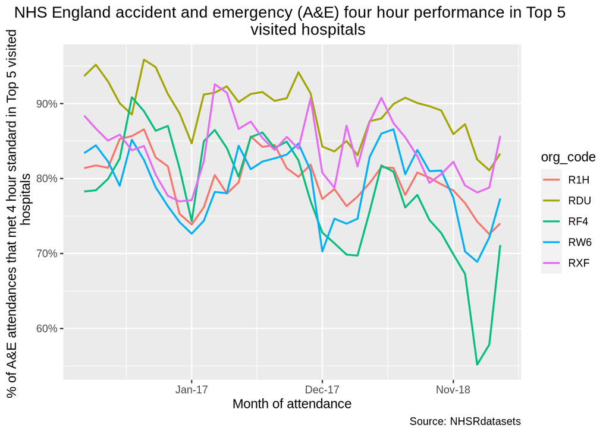

```r
ggplot(Top5_visualready, aes(x=period, y=performance, group=org_code, colour=org_code)) +
  geom_line (size=0.75) + scale_y_continuous(labels = percent) +
  scale_x_date(date_labels = "%b-%y", date_breaks = "11 month")+
  labs(x = "Month of attendance",
       y = "% of A&E attendances that met 4 hour standard in Top 5 visited
       hospitals",
       title = "NHS England accident and emergency (A&E) four hour performance in Top 5
       visited hospitals",
       caption = "Source: NHSRdatasets")+
  theme(plot.title = element_text(hjust = 0.5))
```

# Separating provisionalae_type1 data into training and testing sets

## Indexing to create train and test data

```r
nrow(ae_type1) #to confirm number of rows again
```

```
## [1] 4932
```

```r
prop<-(1-(15/nrow(ae_type1)))
print(prop)
```

```
## [1] 0.9969586
```

```r
set.seed(333)
#Partitioning the raw data into the test and training data.
trainIndex <- createDataPartition(ae_type1$Index, p = prop,
                                  list = FALSE,
                                  times = 1)
head(trainIndex)
```

```
##      Resample1
## [1,]         1
## [2,]         2
## [3,]         3
## [4,]         4
## [5,]         5
## [6,]         6
```

```r
# All records that are in the trainIndex are assigned to the training data.
ae_type1Train <- ae_type1[ trainIndex,]
nrow(ae_type1Train)
```

```
## [1] 4920
```

## Creating Training Dataset

```r
ae_type1Train %>%
  mutate_at(vars(period), format, "%b-%y") %>%
  mutate_at(vars(attendances, breaches), comma) %>%
  head(10) %>%
  kable()
```

| Index | period | org_code | type | attendances | breaches | admissions |
| --- | --- | --- | --- | --- | --- | --- |
| 1 | Mar-17 | RF4 | 1 | 21,289.0 | 2,879.0 | 5060 |
| 4 | Mar-17 | R1H | 1 | 30,210.0 | 5,902.0 | 6943 |
| 9 | Mar-17 | RQM | 1 | 17,414.0 | 2,030.0 | 3597 |
| 11 | Mar-17 | RJ6 | 1 | 6,654.0 | 1,322.0 | 2202 |
| 15 | Mar-17 | RVR | 1 | 12,649.0 | 473.0 | 3360 |
| 17 | Mar-17 | RJ1 | 1 | 12,385.0 | 2,092.0 | 3181 |
| 21 | Mar-17 | RQX | 1 | 10,300.0 | 635.0 | 1684 |
| 23 | Mar-17 | RYJ | 1 | 10,020.0 | 2,632.0 | 3270 |
| 26 | Mar-17 | RJZ | 1 | 17,810.0 | 4,153.0 | 4477 |
| 29 | Mar-17 | RAX | 1 | 9,239.0 | 968.0 | 1839 |

```r
write_csv(ae_type1Train, here("WorkingData", "ae_type1_train.csv"))
```

## Creating Testing Dataset

```r
ae_type1_test  <- ae_type1[-trainIndex,]
nrow(ae_type1_test)
```

```
## [1] 12
```

#### Tabulating and saving TestMarker

```r
ae_type1TestMarker  <- ae_type1_test[1,]
ae_type1TestMarker  %>%
  mutate_at(vars(period), format, "%b-%y") %>%
  mutate_at(vars(attendances, breaches), comma) %>%
  head(10) %>%
  kable()
```

| Index | period | org_code | type | attendances | breaches | admissions |
| --- | --- | --- | --- | --- | --- | --- |
| 318 | Mar-17 | RD1 | 1 | 6,218 | 1,379 | 2103 |

```r
write_csv(ae_type1TestMarker, here("WorkingData", "ae_type1_testmarker.csv"))
```

### Saving remaining test records

```r
ae_type1_test  <- ae_type1_test[2:nrow(ae_type1_test),]
ae_type1_test  %>%
  mutate_at(vars(period), format, "%b-%y") %>%
  mutate_at(vars(attendances, breaches), comma) %>%
  head(10) %>%
  kable()
```

| Index | period | org_code | type | attendances | breaches | admissions |
| --- | --- | --- | --- | --- | --- | --- |
| 2826 | Jul-16 | RGT | 1 | 10,081 | 2,288 | 3123 |
| 2865 | Jul-16 | RM1 | 1 | 10,303 | 1,080 | 2891 |
| 3941 | Apr-16 | RRK | 1 | 9,044 | 1,195 | 2744 |
| 5431 | Dec-17 | RJN | 1 | 4,238 | 1,208 | 971 |
| 5940 | Nov-17 | RNZ | 1 | 3,940 | 209 | 1131 |
| 6727 | Aug-17 | RQ3 | 1 | 3,801 | 86 | 754 |
| 7952 | May-17 | RBL | 1 | 8,270 | 2,120 | 2491 |
| 8427 | Mar-19 | R1K | 1 | 12,753 | 3,178 | 6522 |
| 10489 | Oct-18 | RPA | 1 | 7,710 | 1,750 | 2065 |
| 12390 | May-18 | RA3 | 1 | 4,390 | 348 | 1090 |

```r
write_csv(ae_type1_test, here("WorkingData", "ae_type1_test.csv"))
```